# Risk Factor Analysis

## Outcome Variable

**Outcome Variable:** pers_wast

## Predictor Variables

**Intervention Variable:** mage

**Adjustment Set:**

- arm
- meducyrs
- feducyrs
- W_mhtcm
- W_mwtkg
- W_mbmi
- single
- delta_meducyrs
- delta_feducyrs
- delta_W_mhtcm
- delta_W_mwtkg
- delta_W_mbmi
- delta_single

## Stratifying Variables

The analysis was stratified on these variable(s):

- agecat
- studyid
- country

## Data Summary

| agecat | studyid | country | mage | pers_wast | n_cell | n |
| --- | --- | --- | --- | --- | --- | --- |
| 0-24 months | CMC-V-BCS-2002 | INDIA | [20-30) | 0 | 277 | 373 |
| 0-24 months | CMC-V-BCS-2002 | INDIA | [20-30) | 1 | 19 | 373 |
| 0-24 months | CMC-V-BCS-2002 | INDIA | <20 | 0 | 33 | 373 |
| 0-24 months | CMC-V-BCS-2002 | INDIA | <20 | 1 | 1 | 373 |
| 0-24 months | CMC-V-BCS-2002 | INDIA | >=30 | 0 | 40 | 373 |
| 0-24 months | CMC-V-BCS-2002 | INDIA | >=30 | 1 | 3 | 373 |
| 0-24 months | COHORTS | GUATEMALA | [20-30) | 0 | 499 | 1053 |
| 0-24 months | COHORTS | GUATEMALA | [20-30) | 1 | 16 | 1053 |
| 0-24 months | COHORTS | GUATEMALA | <20 | 0 | 128 | 1053 |
| 0-24 months | COHORTS | GUATEMALA | <20 | 1 | 5 | 1053 |
| 0-24 months | COHORTS | GUATEMALA | >=30 | 0 | 390 | 1053 |
| 0-24 months | COHORTS | GUATEMALA | >=30 | 1 | 15 | 1053 |
| 0-24 months | COHORTS | INDIA | [20-30) | 0 | 2483 | 4068 |
| 0-24 months | COHORTS | INDIA | [20-30) | 1 | 254 | 4068 |
| 0-24 months | COHORTS | INDIA | <20 | 0 | 233 | 4068 |
| 0-24 months | COHORTS | INDIA | <20 | 1 | 40 | 4068 |
| 0-24 months | COHORTS | INDIA | >=30 | 0 | 947 | 4068 |
| 0-24 months | COHORTS | INDIA | >=30 | 1 | 111 | 4068 |
| 0-24 months | COHORTS | PHILIPPINES | [20-30) | 0 | 1589 | 2811 |
| 0-24 months | COHORTS | PHILIPPINES | [20-30) | 1 | 87 | 2811 |
| 0-24 months | COHORTS | PHILIPPINES | <20 | 0 | 327 | 2811 |
| 0-24 months | COHORTS | PHILIPPINES | <20 | 1 | 17 | 2811 |
| 0-24 months | COHORTS | PHILIPPINES | >=30 | 0 | 751 | 2811 |
| 0-24 months | COHORTS | PHILIPPINES | >=30 | 1 | 40 | 2811 |
| 0-24 months | EE | PAKISTAN | [20-30) | 0 | 148 | 374 |
| 0-24 months | EE | PAKISTAN | [20-30) | 1 | 13 | 374 |
| 0-24 months | EE | PAKISTAN | <20 | 0 | 1 | 374 |
| 0-24 months | EE | PAKISTAN | <20 | 1 | 0 | 374 |
| 0-24 months | EE | PAKISTAN | >=30 | 0 | 192 | 374 |
| 0-24 months | EE | PAKISTAN | >=30 | 1 | 20 | 374 |

[output cut: 414 more lines]

The following strata were considered:

- agecat: 0-24 months, studyid: CMC-V-BCS-2002, country: INDIA
- agecat: 0-24 months, studyid: COHORTS, country: GUATEMALA
- agecat: 0-24 months, studyid: COHORTS, country: INDIA
- agecat: 0-24 months, studyid: COHORTS, country: PHILIPPINES
- agecat: 0-24 months, studyid: EE, country: PAKISTAN
- agecat: 0-24 months, studyid: GMS-Nepal, country: NEPAL
- agecat: 0-24 months, studyid: Guatemala BSC, country: GUATEMALA
- agecat: 0-24 months, studyid: iLiNS-Zinc, country: BURKINA FASO
- agecat: 0-24 months, studyid: IRC, country: INDIA
- agecat: 0-24 months, studyid: JiVitA-3, country: BANGLADESH
- agecat: 0-24 months, studyid: Keneba, country: GAMBIA
- agecat: 0-24 months, studyid: LCNI-5, country: MALAWI
- agecat: 0-24 months, studyid: MAL-ED, country: BANGLADESH
- agecat: 0-24 months, studyid: MAL-ED, country: BRAZIL
- agecat: 0-24 months, studyid: MAL-ED, country: INDIA
- agecat: 0-24 months, studyid: MAL-ED, country: NEPAL
- agecat: 0-24 months, studyid: MAL-ED, country: PERU
- agecat: 0-24 months, studyid: MAL-ED, country: SOUTH AFRICA
- agecat: 0-24 months, studyid: MAL-ED, country: TANZANIA, UNITED REPUBLIC OF
- agecat: 0-24 months, studyid: NIH-Birth, country: BANGLADESH
- agecat: 0-24 months, studyid: NIH-Crypto, country: BANGLADESH
- agecat: 0-24 months, studyid: PROBIT, country: BELARUS
- agecat: 0-24 months, studyid: PROVIDE, country: BANGLADESH
- agecat: 0-24 months, studyid: SAS-CompFeed, country: INDIA
- agecat: 0-24 months, studyid: SAS-FoodSuppl, country: INDIA
- agecat: 0-24 months, studyid: TanzaniaChild2, country: TANZANIA, UNITED REPUBLIC OF
- agecat: 0-24 months, studyid: ZVITAMBO, country: ZIMBABWE
- agecat: 0-6 months, studyid: CMC-V-BCS-2002, country: INDIA
- agecat: 0-6 months, studyid: COHORTS, country: PHILIPPINES
- agecat: 0-6 months, studyid: EE, country: PAKISTAN
- agecat: 0-6 months, studyid: GMS-Nepal, country: NEPAL
- agecat: 0-6 months, studyid: IRC, country: INDIA
- agecat: 0-6 months, studyid: JiVitA-3, country: BANGLADESH
- agecat: 0-6 months, studyid: Keneba, country: GAMBIA
- agecat: 0-6 months, studyid: MAL-ED, country: BANGLADESH
- agecat: 0-6 months, studyid: MAL-ED, country: BRAZIL
- agecat: 0-6 months, studyid: MAL-ED, country: INDIA
- agecat: 0-6 months, studyid: MAL-ED, country: NEPAL
- agecat: 0-6 months, studyid: MAL-ED, country: PERU
- agecat: 0-6 months, studyid: MAL-ED, country: SOUTH AFRICA
- agecat: 0-6 months, studyid: MAL-ED, country: TANZANIA, UNITED REPUBLIC OF
- agecat: 0-6 months, studyid: NIH-Birth, country: BANGLADESH
- agecat: 0-6 months, studyid: NIH-Crypto, country: BANGLADESH
- agecat: 0-6 months, studyid: PROBIT, country: BELARUS
- agecat: 0-6 months, studyid: PROVIDE, country: BANGLADESH
- agecat: 0-6 months, studyid: TanzaniaChild2, country: TANZANIA, UNITED REPUBLIC OF
- agecat: 0-6 months, studyid: ZVITAMBO, country: ZIMBABWE
- agecat: 6-24 months, studyid: CMC-V-BCS-2002, country: INDIA
- agecat: 6-24 months, studyid: COHORTS, country: GUATEMALA
- agecat: 6-24 months, studyid: COHORTS, country: INDIA
- agecat: 6-24 months, studyid: COHORTS, country: PHILIPPINES
- agecat: 6-24 months, studyid: EE, country: PAKISTAN
- agecat: 6-24 months, studyid: GMS-Nepal, country: NEPAL
- agecat: 6-24 months, studyid: Guatemala BSC, country: GUATEMALA
- agecat: 6-24 months, studyid: iLiNS-Zinc, country: BURKINA FASO
- agecat: 6-24 months, studyid: IRC, country: INDIA
- agecat: 6-24 months, studyid: JiVitA-3, country: BANGLADESH
- agecat: 6-24 months, studyid: Keneba, country: GAMBIA
- agecat: 6-24 months, studyid: LCNI-5, country: MALAWI
- agecat: 6-24 months, studyid: MAL-ED, country: BANGLADESH
- agecat: 6-24 months, studyid: MAL-ED, country: BRAZIL
- agecat: 6-24 months, studyid: MAL-ED, country: INDIA
- agecat: 6-24 months, studyid: MAL-ED, country: NEPAL
- agecat: 6-24 months, studyid: MAL-ED, country: PERU
- agecat: 6-24 months, studyid: MAL-ED, country: SOUTH AFRICA
- agecat: 6-24 months, studyid: MAL-ED, country: TANZANIA, UNITED REPUBLIC OF
- agecat: 6-24 months, studyid: NIH-Birth, country: BANGLADESH
- agecat: 6-24 months, studyid: NIH-Crypto, country: BANGLADESH
- agecat: 6-24 months, studyid: PROBIT, country: BELARUS
- agecat: 6-24 months, studyid: PROVIDE, country: BANGLADESH
- agecat: 6-24 months, studyid: SAS-CompFeed, country: INDIA
- agecat: 6-24 months, studyid: SAS-FoodSuppl, country: INDIA
- agecat: 6-24 months, studyid: TanzaniaChild2, country: TANZANIA, UNITED REPUBLIC OF
- agecat: 6-24 months, studyid: ZVITAMBO, country: ZIMBABWE

### Dropped Strata

Some strata were dropped due to rare outcomes:

- agecat: 0-24 months, studyid: CMC-V-BCS-2002, country: INDIA
- agecat: 0-24 months, studyid: EE, country: PAKISTAN
- agecat: 0-24 months, studyid: Guatemala BSC, country: GUATEMALA
- agecat: 0-24 months, studyid: IRC, country: INDIA
- agecat: 0-24 months, studyid: LCNI-5, country: MALAWI
- agecat: 0-24 months, studyid: MAL-ED, country: BANGLADESH
- agecat: 0-24 months, studyid: MAL-ED, country: BRAZIL
- agecat: 0-24 months, studyid: MAL-ED, country: INDIA
- agecat: 0-24 months, studyid: MAL-ED, country: NEPAL
- agecat: 0-24 months, studyid: MAL-ED, country: PERU
- agecat: 0-24 months, studyid: MAL-ED, country: SOUTH AFRICA
- agecat: 0-24 months, studyid: MAL-ED, country: TANZANIA, UNITED REPUBLIC OF
- agecat: 0-24 months, studyid: NIH-Birth, country: BANGLADESH
- agecat: 0-24 months, studyid: PROVIDE, country: BANGLADESH
- agecat: 0-6 months, studyid: CMC-V-BCS-2002, country: INDIA
- agecat: 0-6 months, studyid: EE, country: PAKISTAN
- agecat: 0-6 months, studyid: JiVitA-3, country: BANGLADESH
- agecat: 0-6 months, studyid: MAL-ED, country: BANGLADESH
- agecat: 0-6 months, studyid: MAL-ED, country: BRAZIL
- agecat: 0-6 months, studyid: MAL-ED, country: INDIA
- agecat: 0-6 months, studyid: MAL-ED, country: NEPAL
- agecat: 0-6 months, studyid: MAL-ED, country: PERU
- agecat: 0-6 months, studyid: MAL-ED, country: SOUTH AFRICA
- agecat: 0-6 months, studyid: MAL-ED, country: TANZANIA, UNITED REPUBLIC OF
- agecat: 0-6 months, studyid: NIH-Birth, country: BANGLADESH
- agecat: 0-6 months, studyid: NIH-Crypto, country: BANGLADESH
- agecat: 0-6 months, studyid: PROVIDE, country: BANGLADESH
- agecat: 0-6 months, studyid: ZVITAMBO, country: ZIMBABWE
- agecat: 6-24 months, studyid: CMC-V-BCS-2002, country: INDIA
- agecat: 6-24 months, studyid: EE, country: PAKISTAN
- agecat: 6-24 months, studyid: Guatemala BSC, country: GUATEMALA
- agecat: 6-24 months, studyid: IRC, country: INDIA
- agecat: 6-24 months, studyid: LCNI-5, country: MALAWI
- agecat: 6-24 months, studyid: MAL-ED, country: BANGLADESH
- agecat: 6-24 months, studyid: MAL-ED, country: BRAZIL
- agecat: 6-24 months, studyid: MAL-ED, country: INDIA
- agecat: 6-24 months, studyid: MAL-ED, country: NEPAL
- agecat: 6-24 months, studyid: MAL-ED, country: PERU
- agecat: 6-24 months, studyid: MAL-ED, country: SOUTH AFRICA
- agecat: 6-24 months, studyid: MAL-ED, country: TANZANIA, UNITED REPUBLIC OF
- agecat: 6-24 months, studyid: NIH-Birth, country: BANGLADESH
- agecat: 6-24 months, studyid: PROVIDE, country: BANGLADESH

## Methods Detail

We’re interested in the causal parameters $E[Y_a]$ for all values of $a \in \mathcal{A}$. These parameters represent the mean outcome if, possibly contrary to fact, we intervened to set all units to have $A=a$. Under the randomization and positivity assumptions, these are identified by the statistical parameters $\psi_a=E_W[E_{Y|A,W}(Y|A=a,W)]$. In addition, we’re interested in the mean of $Y$, $E[Y]$ under no intervention (the observed mean). We will estimate these parameters by using SuperLearner to fit the relevant likelihood factors – $E_{Y|A,W}(Y|A=a,W)$ and $p(A=a|W)$, and then updating our likelihood fit using a joint TMLE.

For unadjusted analyses ($W=\{\}$), initial likelihoods were estimated using Lrnr_glm to estimate the simple $E(Y|A)$ and Lrnr_mean to estimate $p(A)$. For adjusted analyses, a small library containing Lrnr_glmnet, Lrnr_xgboost, and Lrnr_mean was used.

Having estimated these parameters, we will then use the delta method to estimate relative risks and attributable risks relative to a prespecified baseline level of $A$.

# Results Detail

## Results Plots

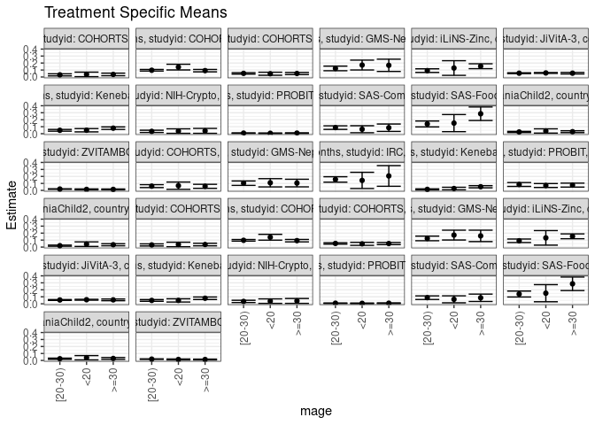

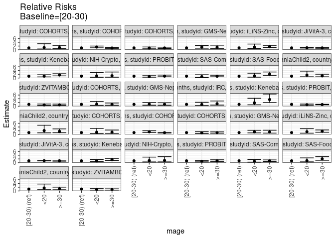

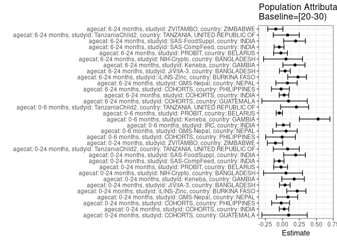

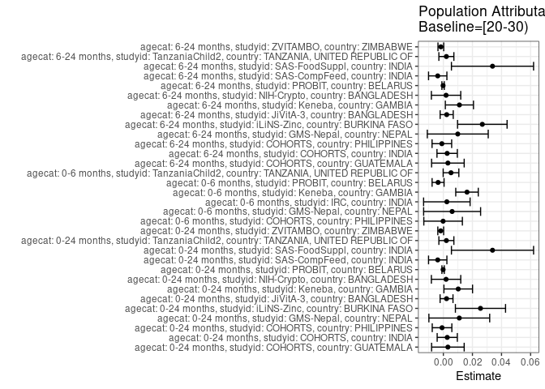

## Results Table

### Parameter: TSM

| agecat | studyid | country | intervention_level | baseline_level | estimate | ci_lower | ci_upper |
| --- | --- | --- | --- | --- | --- | --- | --- |
| 0-24 months | COHORTS | GUATEMALA | [20-30) | NA | 0.0310680 | 0.0160762 | 0.0460598 |
| 0-24 months | COHORTS | GUATEMALA | <20 | NA | 0.0375940 | 0.0052520 | 0.0699360 |
| 0-24 months | COHORTS | GUATEMALA | >=30 | NA | 0.0370370 | 0.0186357 | 0.0554384 |
| 0-24 months | COHORTS | INDIA | [20-30) | NA | 0.0968851 | 0.0856154 | 0.1081548 |
| 0-24 months | COHORTS | INDIA | <20 | NA | 0.1419219 | 0.1010856 | 0.1827582 |
| 0-24 months | COHORTS | INDIA | >=30 | NA | 0.0912833 | 0.0740545 | 0.1085120 |
| 0-24 months | COHORTS | PHILIPPINES | [20-30) | NA | 0.0521336 | 0.0414407 | 0.0628264 |
| 0-24 months | COHORTS | PHILIPPINES | <20 | NA | 0.0470395 | 0.0251799 | 0.0688991 |
| 0-24 months | COHORTS | PHILIPPINES | >=30 | NA | 0.0506109 | 0.0351975 | 0.0660243 |
| 0-24 months | GMS-Nepal | NEPAL | [20-30) | NA | 0.1230485 | 0.0900073 | 0.1560898 |
| 0-24 months | GMS-Nepal | NEPAL | <20 | NA | 0.1711707 | 0.1007868 | 0.2415546 |
| 0-24 months | GMS-Nepal | NEPAL | >=30 | NA | 0.1676071 | 0.0795931 | 0.2556211 |
| 0-24 months | iLiNS-Zinc | BURKINA FASO | [20-30) | NA | 0.0914351 | 0.0657416 | 0.1171287 |
| 0-24 months | iLiNS-Zinc | BURKINA FASO | <20 | NA | 0.1286759 | 0.0241235 | 0.2332283 |
| 0-24 months | iLiNS-Zinc | BURKINA FASO | >=30 | NA | 0.1544010 | 0.1192129 | 0.1895890 |
| 0-24 months | JiVitA-3 | BANGLADESH | [20-30) | NA | 0.0545947 | 0.0483883 | 0.0608011 |
| 0-24 months | JiVitA-3 | BANGLADESH | <20 | NA | 0.0581853 | 0.0518886 | 0.0644821 |
| 0-24 months | JiVitA-3 | BANGLADESH | >=30 | NA | 0.0547998 | 0.0433692 | 0.0662303 |
| 0-24 months | Keneba | GAMBIA | [20-30) | NA | 0.0488113 | 0.0362504 | 0.0613723 |
| 0-24 months | Keneba | GAMBIA | <20 | NA | 0.0498295 | 0.0264218 | 0.0732372 |
| 0-24 months | Keneba | GAMBIA | >=30 | NA | 0.0793652 | 0.0613949 | 0.0973355 |
| 0-24 months | NIH-Crypto | BANGLADESH | [20-30) | NA | 0.0337553 | 0.0174859 | 0.0500247 |
| 0-24 months | NIH-Crypto | BANGLADESH | <20 | NA | 0.0375940 | 0.0052452 | 0.0699428 |
| 0-24 months | NIH-Crypto | BANGLADESH | >=30 | NA | 0.0406504 | 0.0057272 | 0.0755736 |
| 0-24 months | PROBIT | BELARUS | [20-30) | NA | 0.0082468 | 0.0046371 | 0.0118566 |
| 0-24 months | PROBIT | BELARUS | <20 | NA | 0.0062609 | 0.0019798 | 0.0105420 |
| 0-24 months | PROBIT | BELARUS | >=30 | NA | 0.0084754 | 0.0038058 | 0.0131450 |
| 0-24 months | SAS-CompFeed | INDIA | [20-30) | NA | 0.0873329 | 0.0617476 | 0.1129183 |
| 0-24 months | SAS-CompFeed | INDIA | <20 | NA | 0.0639487 | 0.0138363 | 0.1140610 |
| 0-24 months | SAS-CompFeed | INDIA | >=30 | NA | 0.0857093 | 0.0327504 | 0.1386681 |

[output cut: 66 more lines]

### Parameter: E(Y)

| agecat | studyid | country | intervention_level | baseline_level | estimate | ci_lower | ci_upper |
| --- | --- | --- | --- | --- | --- | --- | --- |
| 0-24 months | COHORTS | GUATEMALA | NA | NA | 0.0341880 | 0.0232075 | 0.0451686 |
| 0-24 months | COHORTS | INDIA | NA | NA | 0.0995575 | 0.0903557 | 0.1087594 |
| 0-24 months | COHORTS | PHILIPPINES | NA | NA | 0.0512273 | 0.0430760 | 0.0593786 |
| 0-24 months | GMS-Nepal | NEPAL | NA | NA | 0.1340034 | 0.1066544 | 0.1613523 |
| 0-24 months | iLiNS-Zinc | BURKINA FASO | NA | NA | 0.1169626 | 0.0922087 | 0.1417166 |
| 0-24 months | JiVitA-3 | BANGLADESH | NA | NA | 0.0567829 | 0.0526732 | 0.0608927 |
| 0-24 months | Keneba | GAMBIA | NA | NA | 0.0590421 | 0.0496532 | 0.0684311 |
| 0-24 months | NIH-Crypto | BANGLADESH | NA | NA | 0.0356164 | 0.0221630 | 0.0490699 |
| 0-24 months | PROBIT | BELARUS | NA | NA | 0.0080806 | 0.0045539 | 0.0116073 |
| 0-24 months | SAS-CompFeed | INDIA | NA | NA | 0.0834553 | 0.0601989 | 0.1067118 |
| 0-24 months | SAS-FoodSuppl | INDIA | NA | NA | 0.1733333 | 0.1349698 | 0.2116969 |
| 0-24 months | TanzaniaChild2 | TANZANIA, UNITED REPUBLIC OF | NA | NA | 0.0270019 | 0.0201456 | 0.0338581 |
| 0-24 months | ZVITAMBO | ZIMBABWE | NA | NA | 0.0175697 | 0.0149283 | 0.0202111 |
| 0-6 months | COHORTS | PHILIPPINES | NA | NA | 0.0609613 | 0.0448957 | 0.0770269 |
| 0-6 months | GMS-Nepal | NEPAL | NA | NA | 0.1093474 | 0.0836377 | 0.1350572 |
| 0-6 months | IRC | INDIA | NA | NA | 0.1592040 | 0.1233945 | 0.1950135 |
| 0-6 months | Keneba | GAMBIA | NA | NA | 0.0308975 | 0.0233849 | 0.0384101 |
| 0-6 months | PROBIT | BELARUS | NA | NA | 0.0810551 | 0.0555982 | 0.1065120 |
| 0-6 months | TanzaniaChild2 | TANZANIA, UNITED REPUBLIC OF | NA | NA | 0.0254403 | 0.0186125 | 0.0322681 |
| 6-24 months | COHORTS | GUATEMALA | NA | NA | 0.0341880 | 0.0232075 | 0.0451686 |
| 6-24 months | COHORTS | INDIA | NA | NA | 0.0995575 | 0.0903557 | 0.1087594 |
| 6-24 months | COHORTS | PHILIPPINES | NA | NA | 0.0512273 | 0.0430760 | 0.0593786 |
| 6-24 months | GMS-Nepal | NEPAL | NA | NA | 0.1340034 | 0.1066544 | 0.1613523 |
| 6-24 months | iLiNS-Zinc | BURKINA FASO | NA | NA | 0.1169626 | 0.0922087 | 0.1417166 |
| 6-24 months | JiVitA-3 | BANGLADESH | NA | NA | 0.0567829 | 0.0526732 | 0.0608927 |
| 6-24 months | Keneba | GAMBIA | NA | NA | 0.0590421 | 0.0496532 | 0.0684311 |
| 6-24 months | NIH-Crypto | BANGLADESH | NA | NA | 0.0356164 | 0.0221630 | 0.0490699 |
| 6-24 months | PROBIT | BELARUS | NA | NA | 0.0080806 | 0.0045539 | 0.0116073 |
| 6-24 months | SAS-CompFeed | INDIA | NA | NA | 0.0834553 | 0.0601989 | 0.1067118 |
| 6-24 months | SAS-FoodSuppl | INDIA | NA | NA | 0.1733333 | 0.1349698 | 0.2116969 |
| 6-24 months | TanzaniaChild2 | TANZANIA, UNITED REPUBLIC OF | NA | NA | 0.0270019 | 0.0201456 | 0.0338581 |
| 6-24 months | ZVITAMBO | ZIMBABWE | NA | NA | 0.0175697 | 0.0149283 | 0.0202111 |

### Parameter: RR

| agecat | studyid | country | intervention_level | baseline_level | estimate | ci_lower | ci_upper |
| --- | --- | --- | --- | --- | --- | --- | --- |
| 0-24 months | COHORTS | GUATEMALA | [20-30) | [20-30) | 1.0000000 | 1.0000000 | 1.000000 |
| 0-24 months | COHORTS | GUATEMALA | <20 | [20-30) | 1.2100564 | 0.4512550 | 3.244810 |
| 0-24 months | COHORTS | GUATEMALA | >=30 | [20-30) | 1.1921296 | 0.5963889 | 2.382964 |
| 0-24 months | COHORTS | INDIA | [20-30) | [20-30) | 1.0000000 | 1.0000000 | 1.000000 |
| 0-24 months | COHORTS | INDIA | <20 | [20-30) | 1.4648479 | 1.0744465 | 1.997102 |
| 0-24 months | COHORTS | INDIA | >=30 | [20-30) | 0.9421808 | 0.7553936 | 1.175155 |
| 0-24 months | COHORTS | PHILIPPINES | [20-30) | [20-30) | 1.0000000 | 1.0000000 | 1.000000 |
| 0-24 months | COHORTS | PHILIPPINES | <20 | [20-30) | 0.9022880 | 0.5429753 | 1.499375 |
| 0-24 months | COHORTS | PHILIPPINES | >=30 | [20-30) | 0.9707919 | 0.6723904 | 1.401622 |
| 0-24 months | GMS-Nepal | NEPAL | [20-30) | [20-30) | 1.0000000 | 1.0000000 | 1.000000 |
| 0-24 months | GMS-Nepal | NEPAL | <20 | [20-30) | 1.3910825 | 0.8505918 | 2.275017 |
| 0-24 months | GMS-Nepal | NEPAL | >=30 | [20-30) | 1.3621219 | 0.7548785 | 2.457847 |
| 0-24 months | iLiNS-Zinc | BURKINA FASO | [20-30) | [20-30) | 1.0000000 | 1.0000000 | 1.000000 |
| 0-24 months | iLiNS-Zinc | BURKINA FASO | <20 | [20-30) | 1.4072919 | 0.6464296 | 3.063706 |
| 0-24 months | iLiNS-Zinc | BURKINA FASO | >=30 | [20-30) | 1.6886397 | 1.1982982 | 2.379628 |
| 0-24 months | JiVitA-3 | BANGLADESH | [20-30) | [20-30) | 1.0000000 | 1.0000000 | 1.000000 |
| 0-24 months | JiVitA-3 | BANGLADESH | <20 | [20-30) | 1.0657685 | 0.9194103 | 1.235425 |
| 0-24 months | JiVitA-3 | BANGLADESH | >=30 | [20-30) | 1.0037554 | 0.7896988 | 1.275834 |
| 0-24 months | Keneba | GAMBIA | [20-30) | [20-30) | 1.0000000 | 1.0000000 | 1.000000 |
| 0-24 months | Keneba | GAMBIA | <20 | [20-30) | 1.0208592 | 0.5989626 | 1.739931 |
| 0-24 months | Keneba | GAMBIA | >=30 | [20-30) | 1.6259579 | 1.1567702 | 2.285449 |
| 0-24 months | NIH-Crypto | BANGLADESH | [20-30) | [20-30) | 1.0000000 | 1.0000000 | 1.000000 |
| 0-24 months | NIH-Crypto | BANGLADESH | <20 | [20-30) | 1.1137218 | 0.4153797 | 2.986127 |
| 0-24 months | NIH-Crypto | BANGLADESH | >=30 | [20-30) | 1.2042683 | 0.4496864 | 3.225052 |
| 0-24 months | PROBIT | BELARUS | [20-30) | [20-30) | 1.0000000 | 1.0000000 | 1.000000 |
| 0-24 months | PROBIT | BELARUS | <20 | [20-30) | 0.7591904 | 0.4642880 | 1.241407 |
| 0-24 months | PROBIT | BELARUS | >=30 | [20-30) | 1.0277198 | 0.6754335 | 1.563748 |
| 0-24 months | SAS-CompFeed | INDIA | [20-30) | [20-30) | 1.0000000 | 1.0000000 | 1.000000 |
| 0-24 months | SAS-CompFeed | INDIA | <20 | [20-30) | 0.7322397 | 0.3093512 | 1.733224 |
| 0-24 months | SAS-CompFeed | INDIA | >=30 | [20-30) | 0.9814083 | 0.6471965 | 1.488207 |

[output cut: 66 more lines]

### Parameter: PAR

| agecat | studyid | country | intervention_level | baseline_level | estimate | ci_lower | ci_upper |
| --- | --- | --- | --- | --- | --- | --- | --- |
| 0-24 months | COHORTS | GUATEMALA | [20-30) | NA | 0.0031201 | -0.0080818 | 0.0143219 |
| 0-24 months | COHORTS | INDIA | [20-30) | NA | 0.0026724 | -0.0042557 | 0.0096006 |
| 0-24 months | COHORTS | PHILIPPINES | [20-30) | NA | -0.0009063 | -0.0076521 | 0.0058395 |
| 0-24 months | GMS-Nepal | NEPAL | [20-30) | NA | 0.0109548 | -0.0099526 | 0.0318622 |
| 0-24 months | iLiNS-Zinc | BURKINA FASO | [20-30) | NA | 0.0255275 | 0.0082842 | 0.0427709 |
| 0-24 months | JiVitA-3 | BANGLADESH | [20-30) | NA | 0.0021882 | -0.0022455 | 0.0066219 |
| 0-24 months | Keneba | GAMBIA | [20-30) | NA | 0.0102308 | 0.0003886 | 0.0200730 |
| 0-24 months | NIH-Crypto | BANGLADESH | [20-30) | NA | 0.0018612 | -0.0082359 | 0.0119582 |
| 0-24 months | PROBIT | BELARUS | [20-30) | NA | -0.0001663 | -0.0009866 | 0.0006541 |
| 0-24 months | SAS-CompFeed | INDIA | [20-30) | NA | -0.0038776 | -0.0101843 | 0.0024291 |
| 0-24 months | SAS-FoodSuppl | INDIA | [20-30) | NA | 0.0337984 | 0.0055533 | 0.0620436 |
| 0-24 months | TanzaniaChild2 | TANZANIA, UNITED REPUBLIC OF | [20-30) | NA | 0.0020731 | -0.0030809 | 0.0072270 |
| 0-24 months | ZVITAMBO | ZIMBABWE | [20-30) | NA | -0.0018071 | -0.0038130 | 0.0001988 |
| 0-6 months | COHORTS | PHILIPPINES | [20-30) | NA | -0.0001827 | -0.0134459 | 0.0130805 |
| 0-6 months | GMS-Nepal | NEPAL | [20-30) | NA | 0.0060259 | -0.0135602 | 0.0256120 |
| 0-6 months | IRC | INDIA | [20-30) | NA | 0.0023992 | -0.0135867 | 0.0183852 |
| 0-6 months | Keneba | GAMBIA | [20-30) | NA | 0.0162684 | 0.0085232 | 0.0240137 |
| 0-6 months | PROBIT | BELARUS | [20-30) | NA | -0.0036274 | -0.0077468 | 0.0004920 |
| 0-6 months | TanzaniaChild2 | TANZANIA, UNITED REPUBLIC OF | [20-30) | NA | 0.0052609 | -0.0001296 | 0.0106515 |
| 6-24 months | COHORTS | GUATEMALA | [20-30) | NA | 0.0031201 | -0.0080818 | 0.0143219 |
| 6-24 months | COHORTS | INDIA | [20-30) | NA | 0.0026117 | -0.0043892 | 0.0096127 |
| 6-24 months | COHORTS | PHILIPPINES | [20-30) | NA | -0.0010320 | -0.0077749 | 0.0057110 |
| 6-24 months | GMS-Nepal | NEPAL | [20-30) | NA | 0.0099111 | -0.0110416 | 0.0308638 |
| 6-24 months | iLiNS-Zinc | BURKINA FASO | [20-30) | NA | 0.0267952 | 0.0097628 | 0.0438275 |
| 6-24 months | JiVitA-3 | BANGLADESH | [20-30) | NA | 0.0022899 | -0.0022150 | 0.0067947 |
| 6-24 months | Keneba | GAMBIA | [20-30) | NA | 0.0110402 | 0.0013640 | 0.0207165 |
| 6-24 months | NIH-Crypto | BANGLADESH | [20-30) | NA | 0.0018612 | -0.0082359 | 0.0119582 |
| 6-24 months | PROBIT | BELARUS | [20-30) | NA | -0.0001843 | -0.0009992 | 0.0006306 |
| 6-24 months | SAS-CompFeed | INDIA | [20-30) | NA | -0.0038776 | -0.0101843 | 0.0024291 |
| 6-24 months | SAS-FoodSuppl | INDIA | [20-30) | NA | 0.0337984 | 0.0055533 | 0.0620436 |
| 6-24 months | TanzaniaChild2 | TANZANIA, UNITED REPUBLIC OF | [20-30) | NA | 0.0020731 | -0.0030809 | 0.0072270 |
| 6-24 months | ZVITAMBO | ZIMBABWE | [20-30) | NA | -0.0017260 | -0.0037037 | 0.0002518 |

### Parameter: PAF

| agecat | studyid | country | intervention_level | baseline_level | estimate | ci_lower | ci_upper |
| --- | --- | --- | --- | --- | --- | --- | --- |
| 0-24 months | COHORTS | GUATEMALA | [20-30) | NA | 0.0912621 | -0.3014881 | 0.3654921 |
| 0-24 months | COHORTS | INDIA | [20-30) | NA | 0.0268433 | -0.0452241 | 0.0939417 |
| 0-24 months | COHORTS | PHILIPPINES | [20-30) | NA | -0.0176912 | -0.1582387 | 0.1058015 |
| 0-24 months | GMS-Nepal | NEPAL | [20-30) | NA | 0.0817503 | -0.0877524 | 0.2248396 |
| 0-24 months | iLiNS-Zinc | BURKINA FASO | [20-30) | NA | 0.2182536 | 0.0637392 | 0.3472680 |
| 0-24 months | JiVitA-3 | BANGLADESH | [20-30) | NA | 0.0385363 | -0.0430214 | 0.1137167 |
| 0-24 months | Keneba | GAMBIA | [20-30) | NA | 0.1732795 | -0.0092213 | 0.3227780 |
| 0-24 months | NIH-Crypto | BANGLADESH | [20-30) | NA | 0.0522558 | -0.2773402 | 0.2968051 |
| 0-24 months | PROBIT | BELARUS | [20-30) | NA | -0.0205758 | -0.1278896 | 0.0765275 |
| 0-24 months | SAS-CompFeed | INDIA | [20-30) | NA | -0.0464632 | -0.1224801 | 0.0244056 |
| 0-24 months | SAS-FoodSuppl | INDIA | [20-30) | NA | 0.1949911 | 0.0190527 | 0.3393739 |
| 0-24 months | TanzaniaChild2 | TANZANIA, UNITED REPUBLIC OF | [20-30) | NA | 0.0767757 | -0.1340989 | 0.2484402 |
| 0-24 months | ZVITAMBO | ZIMBABWE | [20-30) | NA | -0.1028541 | -0.2220797 | 0.0047398 |
| 0-6 months | COHORTS | PHILIPPINES | [20-30) | NA | -0.0029965 | -0.2459623 | 0.1925903 |
| 0-6 months | GMS-Nepal | NEPAL | [20-30) | NA | 0.0551078 | -0.1417861 | 0.2180486 |
| 0-6 months | IRC | INDIA | [20-30) | NA | 0.0150703 | -0.0905985 | 0.1105008 |
| 0-6 months | Keneba | GAMBIA | [20-30) | NA | 0.5265297 | 0.2517815 | 0.7003894 |
| 0-6 months | PROBIT | BELARUS | [20-30) | NA | -0.0447520 | -0.0918965 | 0.0003569 |
| 0-6 months | TanzaniaChild2 | TANZANIA, UNITED REPUBLIC OF | [20-30) | NA | 0.2067954 | -0.0268777 | 0.3872947 |
| 6-24 months | COHORTS | GUATEMALA | [20-30) | NA | 0.0912621 | -0.3014881 | 0.3654921 |
| 6-24 months | COHORTS | INDIA | [20-30) | NA | 0.0262335 | -0.0466253 | 0.0940204 |
| 6-24 months | COHORTS | PHILIPPINES | [20-30) | NA | -0.0201450 | -0.1606022 | 0.1033140 |
| 6-24 months | GMS-Nepal | NEPAL | [20-30) | NA | 0.0739616 | -0.0958366 | 0.2174498 |
| 6-24 months | iLiNS-Zinc | BURKINA FASO | [20-30) | NA | 0.2290917 | 0.0786798 | 0.3549478 |
| 6-24 months | JiVitA-3 | BANGLADESH | [20-30) | NA | 0.0403265 | -0.0425313 | 0.1165990 |
| 6-24 months | Keneba | GAMBIA | [20-30) | NA | 0.1869893 | 0.0080734 | 0.3336337 |
| 6-24 months | NIH-Crypto | BANGLADESH | [20-30) | NA | 0.0522558 | -0.2773402 | 0.2968051 |
| 6-24 months | PROBIT | BELARUS | [20-30) | NA | -0.0228066 | -0.1293794 | 0.0737096 |
| 6-24 months | SAS-CompFeed | INDIA | [20-30) | NA | -0.0464632 | -0.1224801 | 0.0244056 |
| 6-24 months | SAS-FoodSuppl | INDIA | [20-30) | NA | 0.1949911 | 0.0190527 | 0.3393739 |
| 6-24 months | TanzaniaChild2 | TANZANIA, UNITED REPUBLIC OF | [20-30) | NA | 0.0767757 | -0.1340989 | 0.2484402 |
| 6-24 months | ZVITAMBO | ZIMBABWE | [20-30) | NA | -0.0982357 | -0.2158204 | 0.0079772 |